# R Notebook

This notebook visualises the year’s worth of typing data from author AL (Alex), and also performs the phase analysis described in `phase_analysis.Rmd`.

```r
library(arrow)
library(ggpubr)
library(reshape2)
library(tidyverse)
library(ggeffects)

readRenviron(".env")

source("utils.R")

dat_dir <- Sys.getenv("DAT_DIR")
man_img_dir <- Sys.getenv("MAN_IMG_DIR")
```

# Load session data

```r
dat_ses <- read_parquet(file.path(dat_dir, "BiAffect_Alex", "dat_ses_alex.parquet"))
```

```r
dat_ses_15 <- dat_ses %>%
  filter(phoneType == "iPhone 15")

dat_ses_15
```

Aggregate by hour.

```r
dat_hour <- dat_ses_15 %>%
  group_by(date, hour) %>%
  summarize(
    medianIKD = mean(medianIKD),
    autocorrectRate = mean(autocorrectRate),
    backspaceRate = mean(backspaceRate),
    totalKeyPresses = sum(totalKeyPresses),
    timezone = timezone[1]
  ) %>%
  ungroup() %>%
  mutate(
    medianIKD = na_if(medianIKD, 0),
    hour = as.integer(hour),
    utc_offset = as.integer(str_extract(timezone, "([+-]\\d+):\\d+", group = 1)),
    timezone = fct_reorder(timezone, utc_offset),
    timestamp = as_datetime(date) + hours(hour)
  )
dat_hour
```

```r
levels(dat_hour$timezone)
```

```
## [1] "UTC-08:00" "UTC-07:00" "UTC-06:00" "UTC-05:00" "UTC-04:00" "UTC+01:00"
## [7] "UTC+02:00" "UTC+08:00" "UTC+09:00"
```

# Plot transitions

Create a data frame that 1) delineates the periods spent contiguously in one time zone and 2) indicates when Alex’s sleep period starts and ends in UTC+00:00 (where her sleep period is defined as from 11pm to 7am, local time).

```r
max_date <- max(dat_hour$date)

dat_nights <- dat_hour %>%
  group_by(date) %>%
  summarize(timezone = last(timezone)) %>%
  filter(timezone != lag(timezone) | date == min(date)) %>% # Current tz not equal to previous tz
  mutate(
    last_date = lead(date, default = max_date) - days(1),
    utc_offset = as.integer(str_extract(timezone, "([+-]\\d+):\\d+", group = 1)),
    night_start = (23 - utc_offset) %% 24,
    night_end = (7 - utc_offset) %% 24,
    night_start2 = case_when(night_end < night_start ~ 0),
    night_end2 = case_when(night_end < night_start ~ night_end),
    night_end = case_when(
      night_end < night_start ~ 23,
      TRUE ~ night_end
    )
  )

dat_nights
```

| date | timezone | last_date | utc_offset | night_start | night_end | night_start2 | night_end2 |
| --- | --- | --- | --- | --- | --- | --- | --- |
| 2023-12-10 | UTC-06:00 | 2023-12-27 | -6 | 5 | 13 | NA | NA |
| 2023-12-28 | UTC+09:00 | 2024-01-06 | 9 | 14 | 22 | NA | NA |
| 2024-01-07 | UTC+08:00 | 2024-01-16 | 8 | 15 | 23 | NA | NA |
| 2024-01-17 | UTC-06:00 | 2024-03-09 | -6 | 5 | 13 | NA | NA |
| 2024-03-10 | UTC-05:00 | 2024-03-30 | -5 | 4 | 12 | NA | NA |
| 2024-03-31 | UTC+02:00 | 2024-04-28 | 2 | 21 | 23 | 0 | 5 |
| 2024-04-29 | UTC-05:00 | 2024-05-31 | -5 | 4 | 12 | NA | NA |
| 2024-06-01 | UTC+01:00 | 2024-06-07 | 1 | 22 | 23 | 0 | 6 |
| 2024-06-08 | UTC-05:00 | 2024-07-11 | -5 | 4 | 12 | NA | NA |
| 2024-07-12 | UTC+09:00 | 2024-07-13 | 9 | 14 | 22 | NA | NA |

[output cut: 8 more lines]

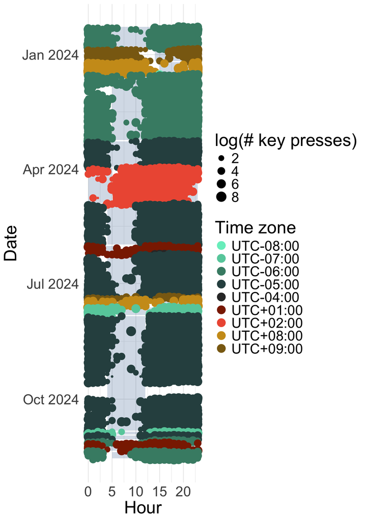

```r
# t_date <- scales::transform_date()

min_date <- as.Date(min(dat_hour$date) - days(1))
max_date <- as.Date(max(dat_hour$date) + days(1))


g_bubble <- ggplot(dat_hour) +
  geom_rect(
    aes(
      xmin = night_start, xmax = night_end,
      ymin = last_date, ymax = date
    ),
    fill = "dodgerblue4",
    alpha = 0.2,
    data = dat_nights) +
  geom_rect(
    aes(
      xmin = night_start2, xmax = night_end2,
      ymin = last_date, ymax = date
    ),
    fill = "dodgerblue4",
    alpha = 0.2,
    data = drop_na(dat_nights)) +
  geom_point(aes(hour, date, size = log(totalKeyPresses), color = timezone)) +
  scale_y_continuous(
    limits = c(max_date, min_date), # Reversed
    transform = c("date", "reverse")
  ) +
  scale_color_manual(values = c(
    "aquamarine2", "aquamarine3", "aquamarine4", "darkslategray", "gray20",
    "orangered4", "tomato2",
    "goldenrod3", "goldenrod4"
  )) +
  labs(x = "Hour", y = "Date", color = "Time zone", size = "log(# key presses)") +
  # ylim(min_date, max_date) +
  guides(color = guide_legend(override.aes = list(size = 5))) +
  theme_minimal() +
  theme(text = element_text(size = 24))

g_bubble
```

```r
# ggsave(file.path(man_img_dir, "bubbles.pdf"))
```

# SVD

Load Alex’s GRSVD data.

```r
dat_svd <- read_parquet(file.path(dat_dir, "BiAffect_Alex", "svd_long_tail.parquet"))

dat_svd
```

Create a graphical element for Figure 3 of the paper.

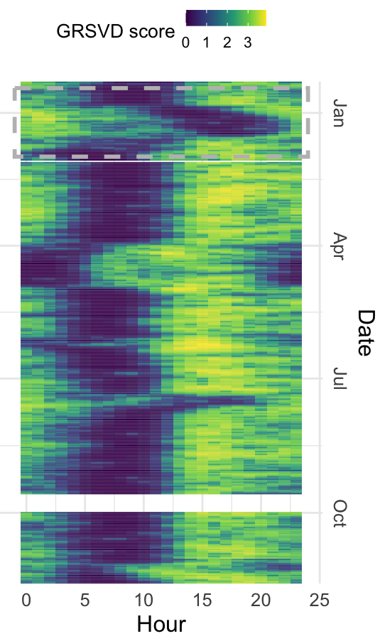

```r
zoom_start <- ymd("2023-12-15")
zoom_end <- ymd("2024-01-31")

ggplot(dat_svd, aes(hour, date)) +
  geom_tile(aes(fill = value), width = 1, height = 1) +
  scale_y_continuous(
    transform = c("date", "reverse"),
    position = "right",
    expand = expansion()
  ) +
  annotate("rect", xmin = -1, xmax = 24, ymin = zoom_start, ymax = zoom_end, fill = NA, linetype = "dashed", color = "grey", linewidth = 1) +
  scale_fill_continuous(type = "viridis", guide = guide_colorbar(position = "top"), limits = c(0, NA)) +
  labs(x = "Hour", y = "Date", fill = "GRSVD score") +
  theme_minimal() +
  theme(
    text = element_text(size = 12),
    axis.text.y.right = element_text(angle = -90, hjust = 0.5),
    legend.title = element_text(size = 10),
    legend.text = element_text(size = 8),
    legend.key.size = unit(0.3, "cm"),
    plot.margin = unit(c(0,1,0,0), "mm")
  )
```

```r
# ggsave(file.path(man_img_dir, "alex_phase_analysis", "svd_alex_right_ggplot.pdf"))
```

Create a zoomed-in version of the GRSVD plot (for a powerpoint slide).

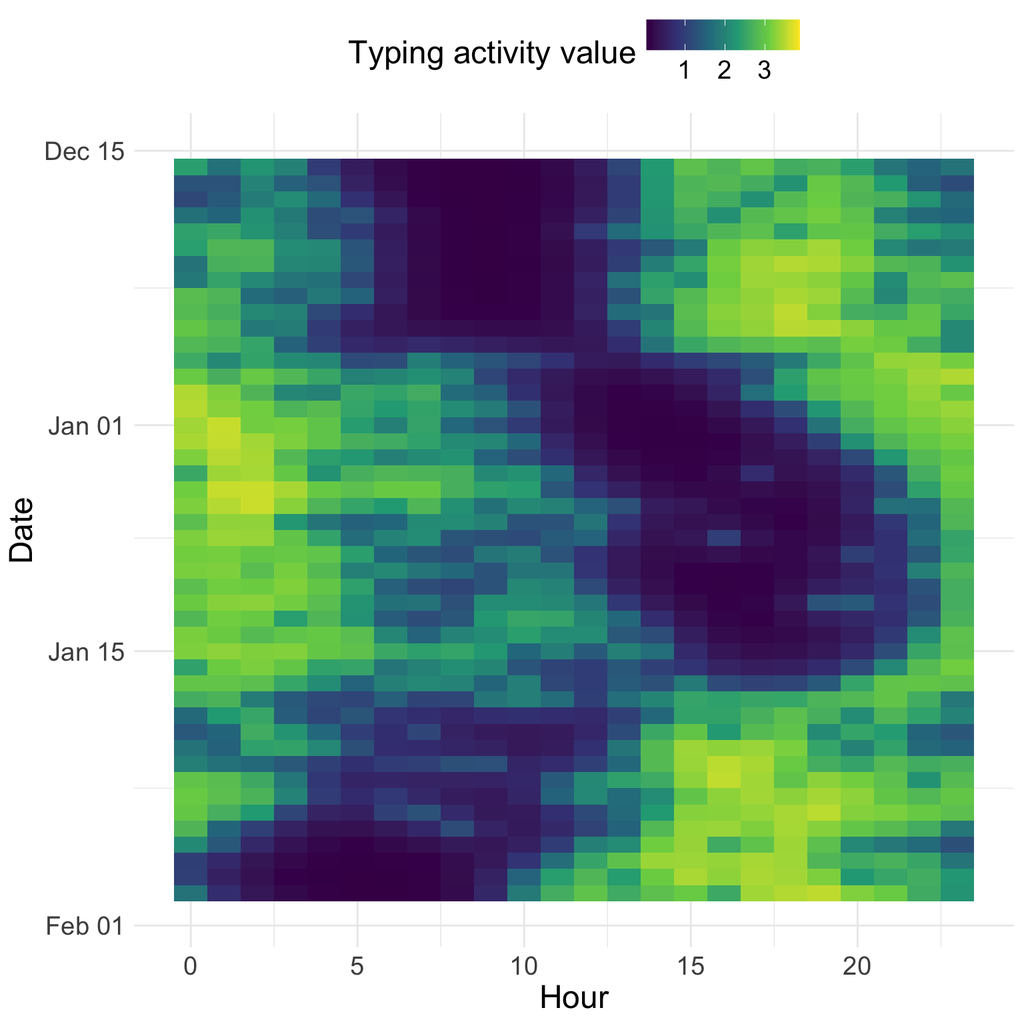

```r
zoom_start <- ymd("2023-12-15")
zoom_end <- ymd("2024-01-31")

ggplot(dat_svd, aes(hour, date)) +
  geom_tile(aes(fill = value), width = 1, height = 1) +
  scale_y_continuous(
    limits = c(zoom_end, zoom_start), # Reversed
    transform = c("date", "reverse")
  ) +
  scale_fill_continuous(type = "viridis", guide = guide_colorbar(position = "top")) +
  labs(x = "Hour", y = "Date", fill = "Typing activity value") +
  theme_minimal() +
  theme(text = element_text(size = 18))
```

Get the exact moment BiAffect records a time zone transition.

```r
dat_transition <- dat_ses_15 %>%
  mutate(
    utc_offset = as.integer(str_extract(timezone, "([+-]\\d+):\\d+", group = 1)),
    timezone = fct_reorder(timezone, utc_offset),
    prev_timezone = lag(timezone)
  ) %>%
  filter(timezone != prev_timezone | is.na(prev_timezone)) %>%
  select(session_timestamp, timezone, prev_timezone) %>%
  mutate(next_timestamp = lead(session_timestamp))

# write_parquet(dat_transition,
#               file.path(dat_dir, "BiAffect_Alex", "dat_transition_alex.parquet"))

dat_transition
```

Plot the GRSVD values over time for Alex’s trip to Asia.

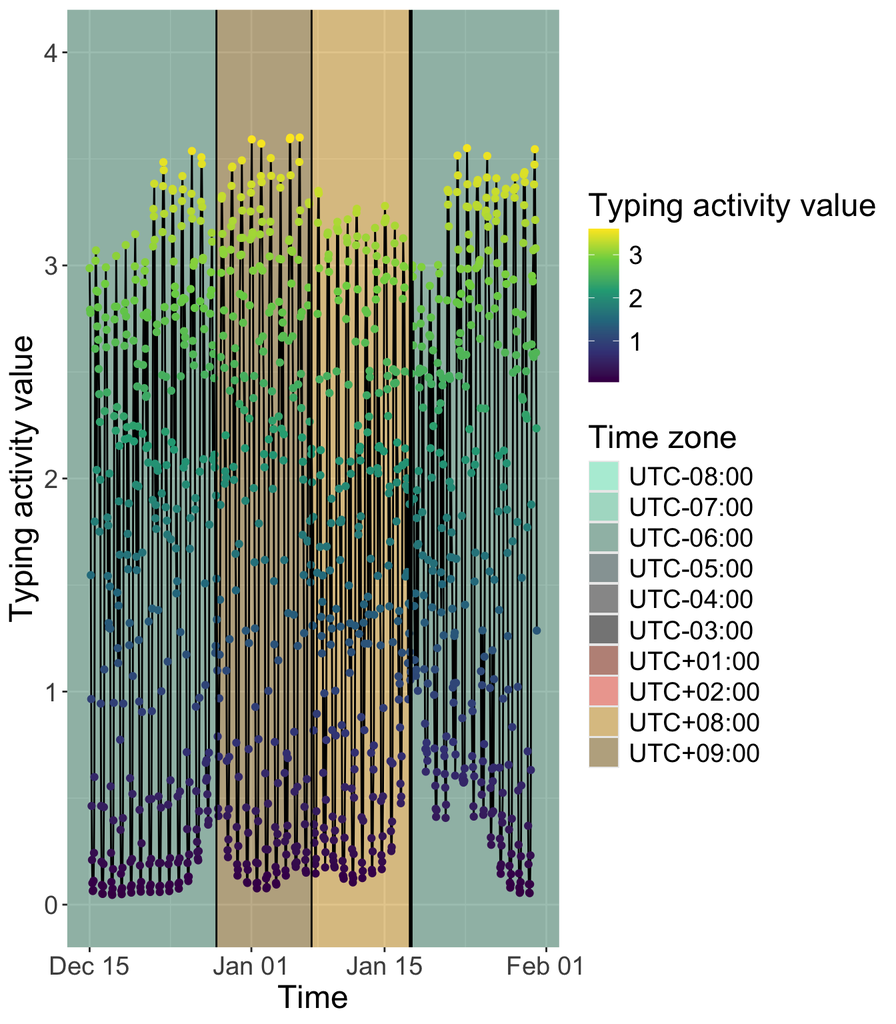

```r
zoom_start_dt <- as_datetime(zoom_start)
zoom_end_dt <- as_datetime(zoom_end)

dat_svd_ts <- dat_svd %>%
  mutate(timestamp = as_datetime(date) + hours(hour)) %>%
  filter(timestamp >= zoom_start_dt,
         timestamp <= zoom_end_dt)

g_svd <- ggplot(dat_svd_ts) +
  geom_rect(aes(xmin = session_timestamp, xmax = next_timestamp,
                ymin = -1, ymax = 5, fill = timezone),
            alpha = 0.5, data = dat_transition) +
  geom_line(aes(timestamp, value)) +
  geom_point(aes(timestamp, value, color = value)) +
  scale_color_continuous(type = "viridis") +
  scale_fill_manual(values = c(
    "aquamarine2", "aquamarine3", "aquamarine4", "darkslategray", "gray20",
    "black", "orangered4", "tomato2",
    "goldenrod3", "goldenrod4"
  )) +
  geom_vline(aes(xintercept = session_timestamp), data = dat_transition) +
  labs(x = NULL, y = "Typing activity value", color = "Typing activity value", fill = "Time zone") +
  coord_cartesian(xlim = c(zoom_start_dt, zoom_end_dt), ylim = c(0, 4))

# So we can easily combine g_svd with other plots later on
g_svd +
  xlab("Time") +
  theme(text = element_text(size = 18))
```

```r
# ggsave(file.path(man_img_dir, "svd_fluctuations_label2.pdf"))
```

## Relation to keyboard metrics

Here we eyeball whether there are any obvious relationships between the GRSVD rhythm disturbances and the BiAffect metrics. Unfortunately, no such relationship is apparent.

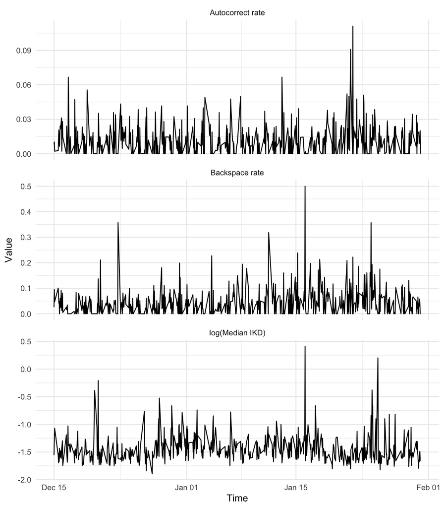

```r
tmp <- dat_hour %>%
  mutate(log_medianIKD = log(medianIKD)) %>%
  pivot_longer(c(backspaceRate, autocorrectRate, log_medianIKD), names_to = "variable") %>%
  filter(timestamp >= zoom_start_dt, timestamp <= zoom_end_dt)

var_labs <- c(
  backspaceRate = "Backspace rate",
  autocorrectRate = "Autocorrect rate",
  log_medianIKD = "log(Median IKD)"
)

g_vars <- ggplot(tmp, aes(timestamp, value)) +
  geom_line() +
  xlim(zoom_start_dt, zoom_end_dt) +
  facet_wrap(~ variable, ncol = 1, scales = "free_y",
             labeller = as_labeller(var_labs)) +
  labs(x = "Time", y = "Value") +
  theme_minimal()

g_vars
```

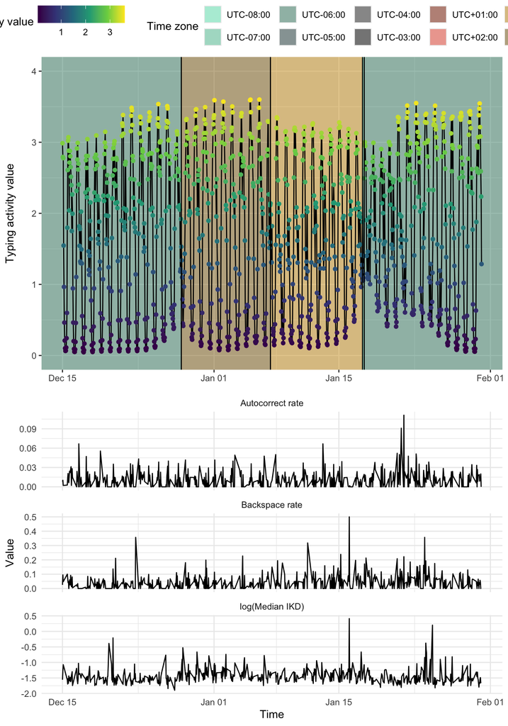

```r
ggarrange(g_svd, g_vars, ncol = 1, align = "v", common.legend = TRUE)
```

```r
filter_width <- 7 * 24 # Seven days

variances <- vector("numeric", nrow(dat_svd_ts))
quantiles <- vector("numeric", nrow(dat_svd_ts))
specs <- matrix(nrow = nrow(dat_svd_ts), ncol = 90)

for (i in 1:nrow(dat_svd_ts)) {
  window_start <- i - filter_width / 2
  window_end <- i + filter_width / 2

  if (window_start > 1 && window_end < nrow(dat_svd_ts)) {
    values <- dat_svd_ts$value[window_start:window_end]
    values_ts <- ts(values, frequency = 24)

    variances[i] <- var(values)
    quantiles[i] <- quantile(values, 0.05)
    specs[i,] <- spectrum(values_ts, plot = FALSE, span = c(3, 5))$spec
  } else {
    variances[i] <- NA
    quantiles[i] <- NA
    specs[i,] <- NA
  }
}
```

```r
freqs <- seq(0, 12, length.out = dim(specs)[2])

spec_df <- melt(specs) %>%
  rename(timestamp = Var1, frequency = Var2) %>%
  mutate(
    timestamp = rep(dat_svd_ts$timestamp, times = length(freqs)),
    frequency = rep(freqs, each = length(dat_svd_ts$timestamp))
  )

spec_df
```

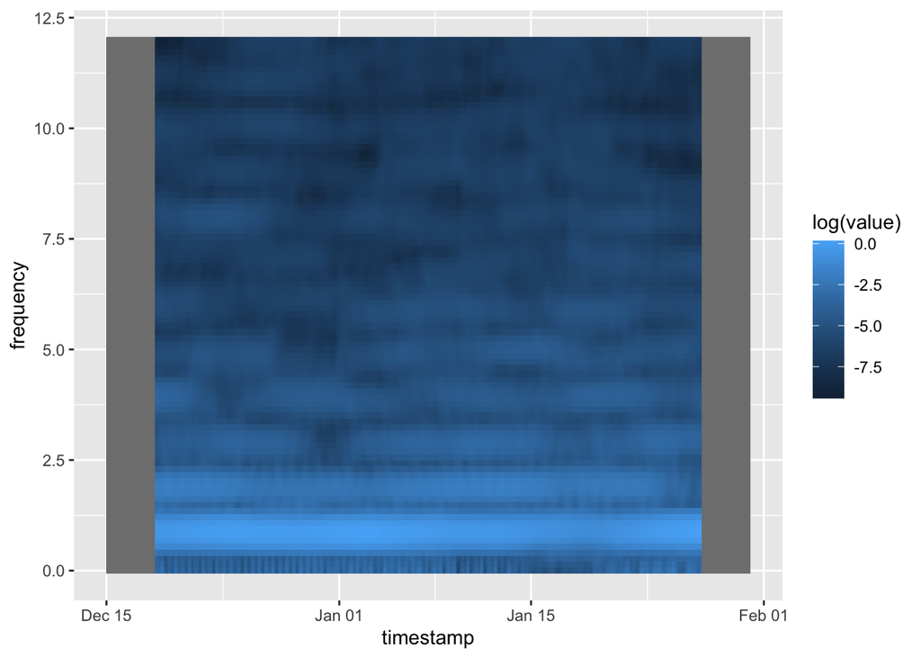

```r
g_spec <- ggplot(spec_df, aes(timestamp, frequency)) +
  geom_raster(aes(fill = log(value)))

g_spec
```

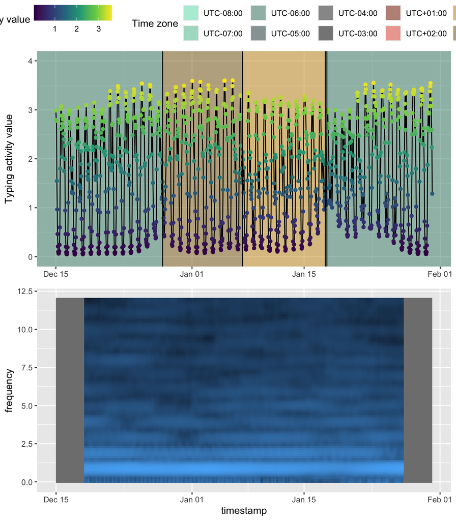

```r
ggarrange(g_svd, g_spec, ncol = 1, common.legend = TRUE, align = "v")
```

The quantiles show some promise for capturing the disturbances shown in the GRSVD line plot.

```
## Ignoring unknown labels:
## • fill : "Timezone"
```

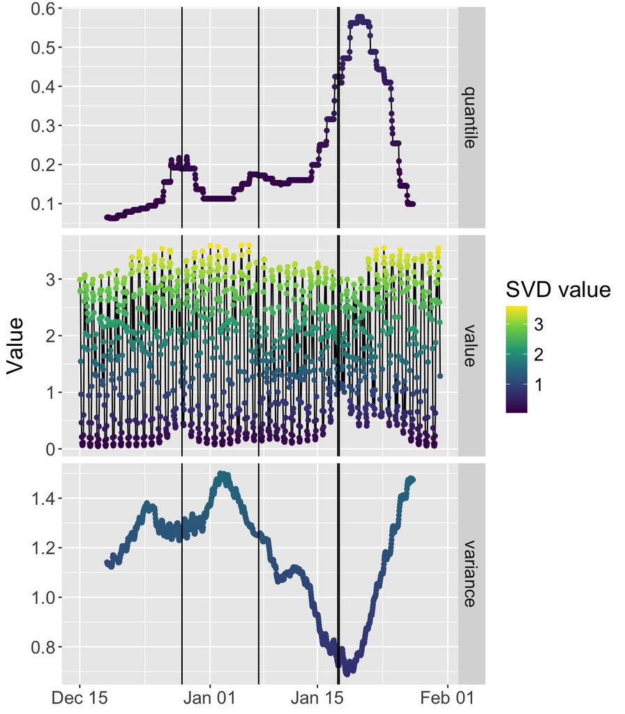

```r
dat_svd_var <- dat_svd_ts %>%
  mutate(
    variance = variances,
    quantile = quantiles
  ) %>%
  pivot_longer(c(value, variance, quantile), names_to = "variable")

ggplot(dat_svd_var) +
  geom_line(aes(timestamp, value)) +
  geom_point(aes(timestamp, value, color = value)) +
  scale_color_continuous(type = "viridis") +
  facet_grid(rows = vars(variable), scales = "free_y") +
  geom_vline(aes(xintercept = session_timestamp), data = dat_transition) +
  labs(x = NULL, y = "Value", color = "SVD value", fill = "Timezone") +
  coord_cartesian(xlim = c(zoom_start_dt, zoom_end_dt)) +
  theme(text = element_text(size = 18))
```

# Fourier analysis SVD

Any obvious and meaningful changes in Fourier periodogram before and during the trip? Not that I can see.

Whole time series.

```r
# 24 observations per day
svd_ts <- ts(dat_svd_ts$value, frequency = 24)

sp <- spectrum(svd_ts, spans = c(3, 5))
```

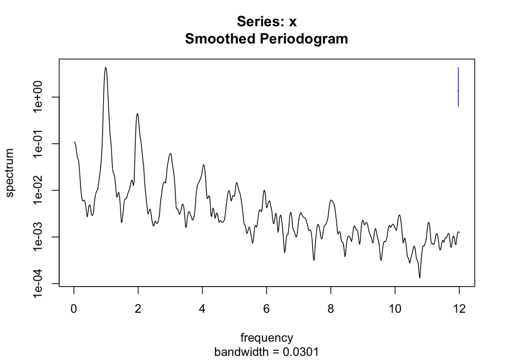

Section surrounding flight to Japan: 2023-12-25 - 2024-01-01

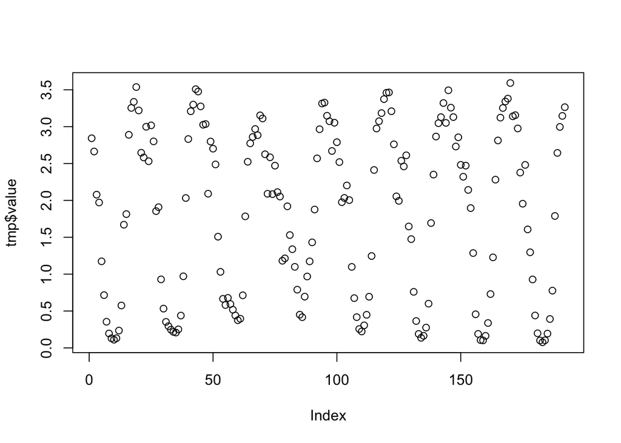

```r
tmp <- dat_svd_ts %>%
  filter(ymd("2023-12-25") <= date, date <= ymd("2024-01-01"))

plot(tmp$value)
```

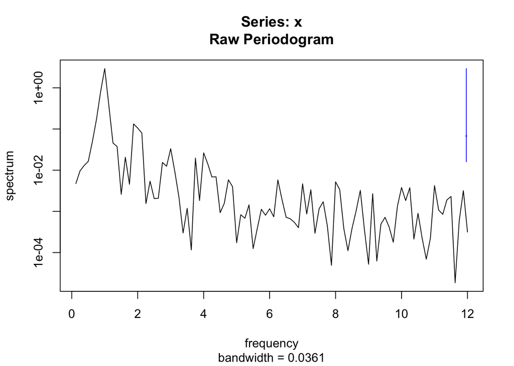

```r
svd_ts_japan <- ts(tmp$value, frequency = 24)

spectrum(svd_ts_japan)
```

Before flight to Japan: 2023-12-15 - 2023-12-23

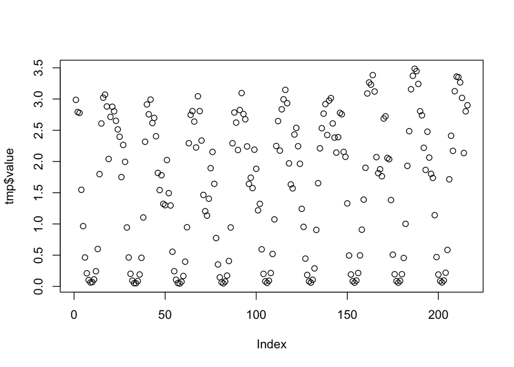

```r
tmp <- dat_svd_ts %>%
  filter(ymd("2023-12-15") <= date, date <= ymd("2023-12-23"))

plot(tmp$value)
```

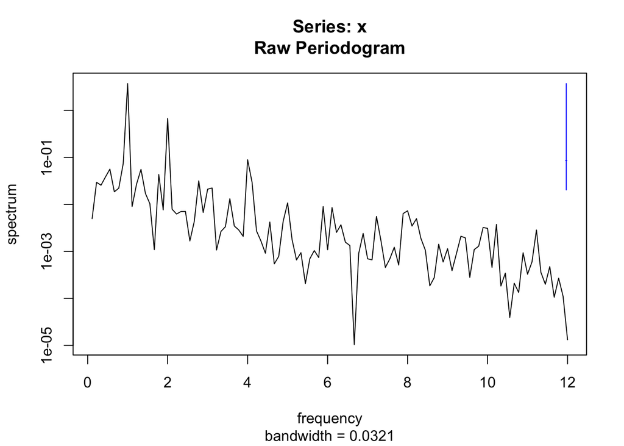

```r
svd_ts_chicago <- ts(tmp$value, frequency = 24)

spectrum(svd_ts_chicago)
```

# Combining bubble and fluctuation plots

Figure elements for an older version of the paper.

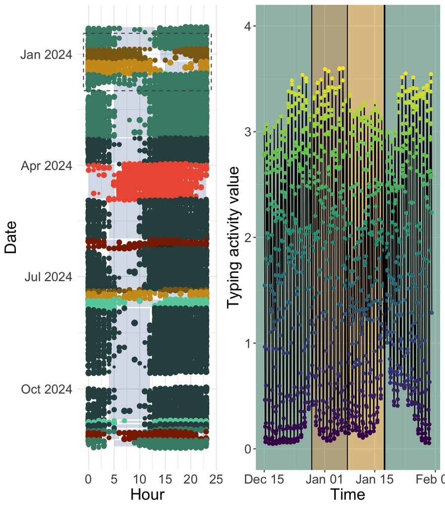

```r
g_bubble2 <- g_bubble +
  theme(text = element_text(size = 18)) +
  scale_size(range = c(1, 3)) +
  geom_rect(
    aes(xmin = -1, xmax = 24, ymin = zoom_start, ymax = zoom_end),
    fill = NA, linetype = "dashed", color = "grey30", linejoin = "round",
    data = data.frame(x = 1)) # Dummy data frame to prevent redrawing

g_svd2 <- g_svd +
  xlab("Time") +
  theme(
    text = element_text(size = 18),
    legend.text = element_text(size = 14)
  ) +
  guides(fill = "none")

ggarrange(g_bubble2, g_svd2, legend = "none")
```

```r
# ggsave(file.path(man_img_dir, "alex_fluctuations", "alex_fluctuations_no_legend.pdf"))
```

[figure not shown]

```r
g_legends <- ggarrange(
  get_legend(g_bubble2, position = "top"),
  get_legend(g_svd2, position = "top"),
  widths = c(4, 1)
)

g_legends
```

```r
# ggsave(file.path(man_img_dir, "alex_fluctuations", "alex_fluctuations_legend.pdf"))
```

# Combining bubble and SVD plots

Figure elements for an older version of the paper.

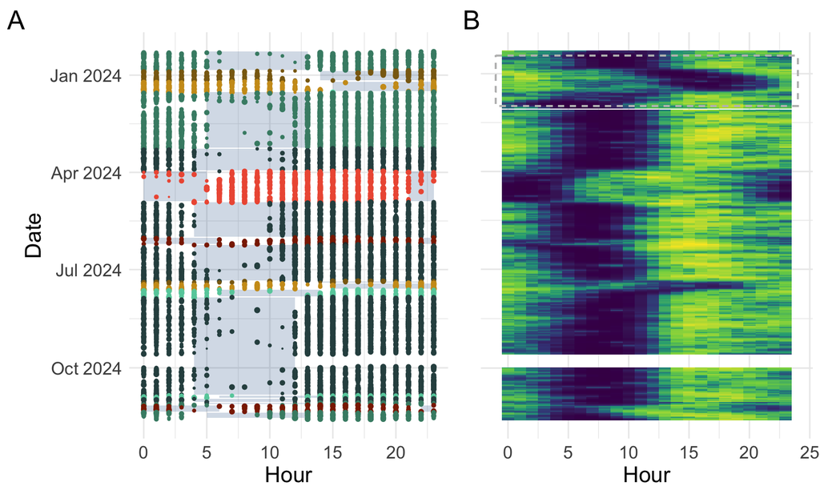

```r
g_bubble3 <- g_bubble +
  scale_size(range = c(0.1, 1.5)) +
  labs(tag = "A") +
  theme(text = element_text(size = 16))

# geom_rect(
#     aes(
#       xmin = night_start, xmax = night_end,
#       ymin = last_date, ymax = date
#     ),
#     fill = "dodgerblue4",
#     alpha = 0.2,
#     data = dat_nights) +
#   geom_rect(
#     aes(
#       xmin = night_start2, xmax = night_end2,
#       ymin = last_date, ymax = date
#     ),
#     fill = "dodgerblue4",
#     alpha = 0.2,
#     data = drop_na(dat_nights)) +
#   geom_point(aes(hour, date, size = log(totalKeyPresses), color = timezone)) +
#   scale_y_continuous(
#     limits = c(max_date, min_date), # Reversed
#     transform = c("date", "reverse")
#   ) +

g_svd3 <- ggplot(dat_svd, aes(hour, date)) +
  geom_tile(aes(fill = value), width = 1, height = 1) +
  geom_rect(aes(xmin = -1, xmax = 24, ymin = zoom_end, ymax = zoom_start),
            fill = NA, color = "grey", linetype = "dashed") +
  # ymin = last_date, ymax = date
  xlab("Hour") +
  scale_fill_continuous(type = "viridis") +
  scale_y_continuous(
    transform = c("date", "reverse")
  ) +
  labs(x = "Hour", tag = "B", fill = "SVD value") +
  theme_minimal() +
  theme(
    text = element_text(size = 16),
    axis.title.y = element_blank(),
    axis.text.y = element_blank(),
    axis.ticks.y = element_blank()
  )

ggarrange(g_bubble3, g_svd3, nrow = 1, widths = c(5, 4), legend = "none")
```

```r
# ggsave(file.path(man_img_dir, "alex_phase_analysis", "phase_analysis_top2.pdf"))
```

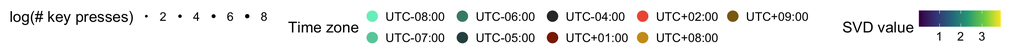

```r
g_legends2 <- ggarrange(
  get_legend(g_bubble3, position = "top"),
  get_legend(g_svd3, position = "top"),
  widths = c(4, 1)
)

g_legends2
```

```r
# ggsave(file.path(man_img_dir, "alex_phase_analysis", "phase_analysis_legend.pdf"))
```

# Data from pull 2025-01-09

Visualisation and exploration of a second data pull.

```r
# Second pull
dat_ses_p2 <- read_parquet(file.path(dat_dir, "BiAffect_Alex",
                                     "dat_ses_alex_pull_2025-01-09.parquet"))
```

```r
dat_ses_p2_15 <- dat_ses_p2 %>%
  filter(phoneType == "iPhone 15")

dat_ses_p2_15
```

```r
dat_hour_p2 <- dat_ses_p2_15 %>%
  group_by(date, hour) %>%
  summarize(
    medianIKD = mean(medianIKD),
    autocorrectRate = mean(autocorrectRate),
    backspaceRate = mean(backspaceRate),
    totalKeyPresses = sum(totalKeyPresses),
    upright = mean(upright),
    timezone = timezone[1]
  ) %>%
  ungroup() %>%
  mutate(
    medianIKD = na_if(medianIKD, 0),
    hour = as.integer(hour),
    utc_offset = as.integer(str_extract(timezone, "([+-]\\d+):\\d+", group = 1)),
    timezone = fct_reorder(timezone, utc_offset),
    timestamp = as_datetime(date) + hours(hour)
  )
max_date_tmp <- max(dat_hour_p2$date)

dat_nights_p2 <- dat_hour_p2 %>%
  group_by(date) %>%
  summarize(timezone = last(timezone)) %>%
  filter(timezone != lag(timezone) | date == min(date)) %>% # Current tz not equal to previous tz
  mutate(
    last_date = lead(date, default = max_date_tmp) - days(1),
    utc_offset = as.integer(str_extract(timezone, "([+-]\\d+):\\d+", group = 1)),
    night_start = (23 - utc_offset) %% 24,
    night_end = (7 - utc_offset) %% 24,
    night_start2 = case_when(night_end < night_start ~ 0),
    night_end2 = case_when(night_end < night_start ~ night_end),
    night_end = case_when(
      night_end < night_start ~ 23,
      TRUE ~ night_end
    )
  )

min_date_p2 <- as.Date(min(dat_hour_p2$date) - days(1))
max_date_p2 <- as.Date(max(dat_hour_p2$date) + days(1))
```

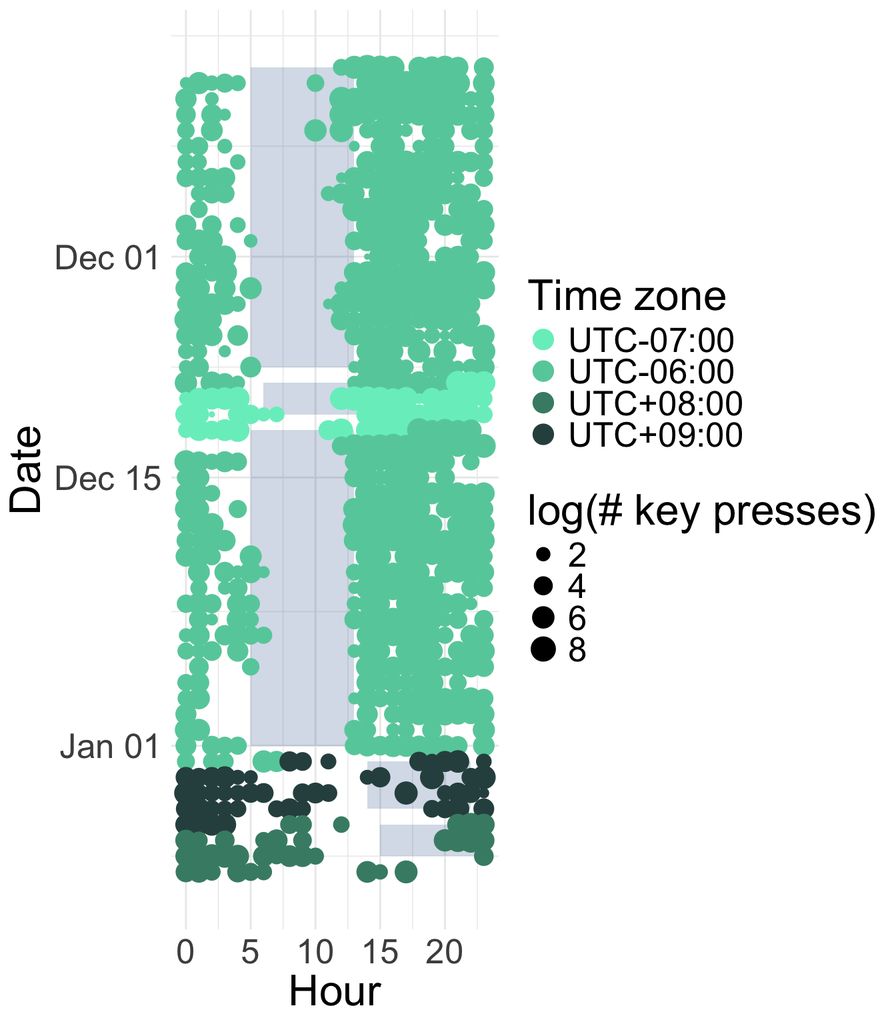

```r
ggplot(dat_hour_p2) +
  geom_rect(
    aes(
      xmin = night_start, xmax = night_end,
      ymin = last_date, ymax = date
    ),
    fill = "dodgerblue4",
    alpha = 0.2,
    data = dat_nights_p2) +
  geom_rect(
    aes(
      xmin = night_start2, xmax = night_end2,
      ymin = last_date, ymax = date
    ),
    fill = "dodgerblue4",
    alpha = 0.2,
    data = drop_na(dat_nights_p2)) +
  geom_point(aes(hour, date, size = log(totalKeyPresses), color = timezone)) +
  scale_y_continuous(
    limits = c(max_date_p2, min_date_p2), # Reversed
    transform = c("date", "reverse")
  ) +
  scale_color_manual(values = c(
    "aquamarine2", "aquamarine3", "aquamarine4", "darkslategray", "gray20",
    "orangered4", "tomato2",
    "goldenrod3", "goldenrod4"
  )) +
  labs(x = "Hour", y = "Date", color = "Time zone", size = "log(# key presses)") +
  # ylim(min_date, max_date) +
  guides(color = guide_legend(override.aes = list(size = 5))) +
  theme_minimal() +
  theme(text = element_text(size = 24))
```

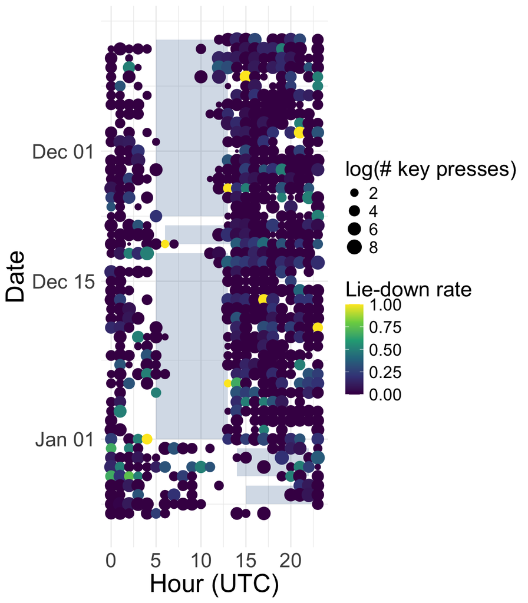

```r
ggplot(dat_hour_p2) +
  geom_rect(
    aes(
      xmin = night_start, xmax = night_end,
      ymin = last_date, ymax = date
    ),
    fill = "dodgerblue4",
    alpha = 0.2,
    data = dat_nights_p2) +
  geom_rect(
    aes(
      xmin = night_start2, xmax = night_end2,
      ymin = last_date, ymax = date
    ),
    fill = "dodgerblue4",
    alpha = 0.2,
    data = drop_na(dat_nights_p2)) +
  geom_point(aes(hour, date, size = log(totalKeyPresses), color = 1 - upright)) +
  scale_y_continuous(
    limits = c(max_date_p2, min_date_p2), # Reversed
    transform = c("date", "reverse")
  ) +
  scale_color_continuous(type = "viridis", guide = "colorbar") +
  labs(x = "Hour (UTC)", y = "Date", color = "Lie-down rate", size = "log(# key presses)") +
  # ylim(min_date, max_date) +
  theme_minimal() +
  theme(
    text = element_text(size = 24),
    legend.text = element_text(size = 16),
    legend.title = element_text(size = 20, hjust = 0)
  )
```

```r
# ggsave(file.path("images", "orientation_alex_2025.pdf"))
```

Autocorrect-backspace trajectory. No obvious patterns.

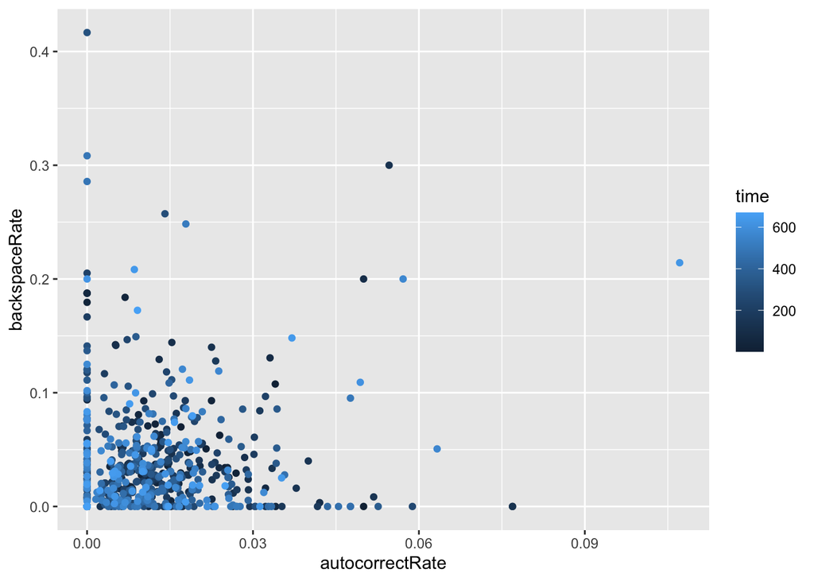

```r
tmp <- dat_hour_p2 %>%
  ungroup() %>%
  mutate(time = 1:n())

ggplot(tmp, aes(autocorrectRate, backspaceRate)) +
  geom_point(aes(color = time))
```

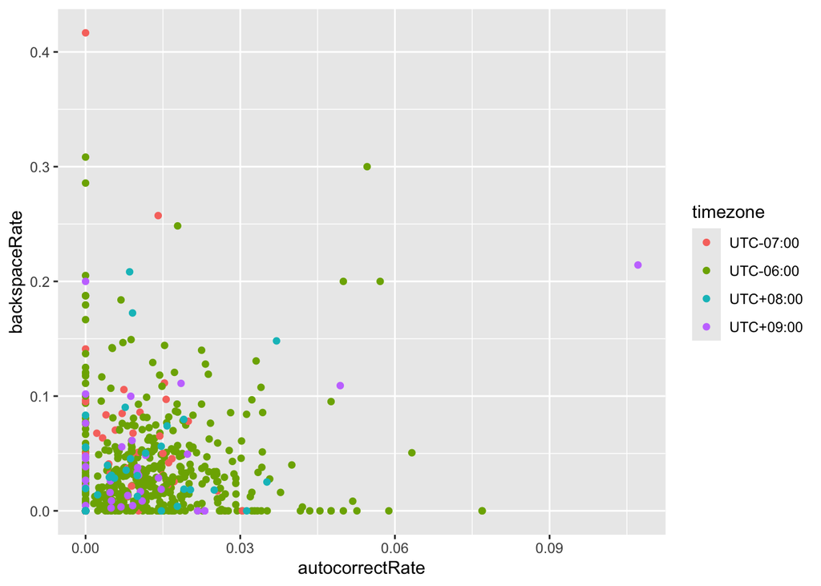

```r
ggplot(tmp, aes(autocorrectRate, backspaceRate)) +
  geom_point(aes(color = timezone))
```

Moving average of autocorrect rate and backspace rate. Rolling window of 24 hours, advancing by one hour.

```r
n_days <- n_distinct(dat_ses_p2_15$date)

filter_width <- 24 # One day
start_dt <- as_datetime(min(dat_ses_p2_15$date))
end_dt <- as_datetime(max(dat_ses_p2_15$date) + days(1))

ac_rates <- vector("numeric", 24 * n_days)
bs_rates <- vector("numeric", 24 * n_days)

for (i in 1:(24 * n_days)) {
  window_start <- start_dt + hours(i - filter_width / 2)
  window_end <- start_dt + hours(i + filter_width / 2)

  if (window_start > start_dt && window_end < end_dt) {
    df <- dat_ses_p2_15 %>%
      filter(session_timestamp >= window_start, session_timestamp < window_end)

    ac_rates[i] <- mean(df$autocorrectRate)
    bs_rates[i] <- mean(df$backspaceRate)
  } else {
    ac_rates[i] <- NA
    bs_rates[i] <- NA
  }
}
```

```r
tz_transitions_p2 <- dat_hour_p2 %>%
  filter(timezone != lag(timezone) | timestamp == min(timestamp)) %>%
  select(timezone, timestamp)

tz_transitions_p2
```

| timezone | timestamp |
| --- | --- |
| UTC-06:00 | 2024-11-19 12:00:00 |
| UTC-07:00 | 2024-12-09 21:00:00 |
| UTC-06:00 | 2024-12-12 18:00:00 |
| UTC+09:00 | 2025-01-02 08:00:00 |
| UTC+08:00 | 2025-01-06 08:00:00 |

```r
ac_bs_df <- data.frame(
  autocorrect = ac_rates,
  backspace = bs_rates,
  time = start_dt + hours(1:(24 * n_days))
) %>%
  left_join(tz_transitions_p2, by = c("time" = "timestamp")) %>%
  fill(timezone, .direction = "downup")

ac_bs_df
```

There is a little separation for UTC-07:00 from UTC+08:00 and UTC+09:00, but almost all points overlap with UTC-06:00.

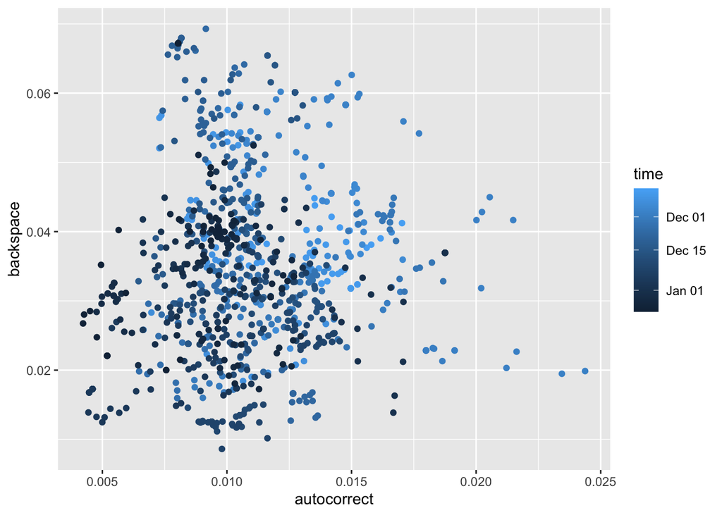

```r
ggplot(ac_bs_df, aes(autocorrect, backspace)) +
  geom_point(aes(color = time)) +
  scale_color_continuous(transform = c("time", "reverse"))
```

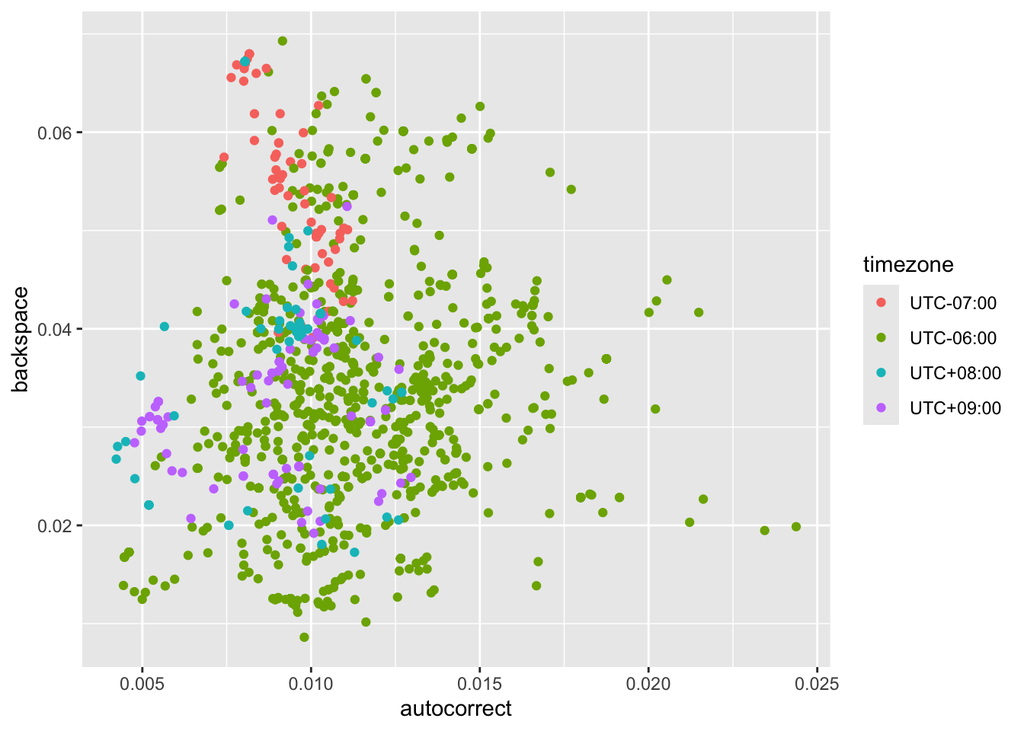

```r
ggplot(ac_bs_df, aes(autocorrect, backspace)) +
  geom_point(aes(color = timezone))
```

```r
# ggsave(file.path("images", "autocorrect_backspace_alex.pdf"))
```

# Pull 2025-02-21

Quick visualisation of third data pull, which also includes the previous pulls.

```r
dat_ses_p3 <- read_parquet(file.path(dat_dir, "BiAffect_Alex", "dat_ses_alex_pull_2025-02-21.parquet"))
```

```r
dat_ses_15_p3 <- dat_ses_p3 %>%
  filter(phoneType == "iPhone 15")

dat_ses_15_p3
```

```r
dat_hour_p3 <- dat_ses_15_p3 %>%
  group_by(date, hour) %>%
  summarize(
    medianIKD = mean(medianIKD),
    autocorrectRate = mean(autocorrectRate),
    backspaceRate = mean(backspaceRate),
    totalKeyPresses = sum(totalKeyPresses),
    timezone = timezone[1]
  ) %>%
  ungroup() %>%
  mutate(
    medianIKD = na_if(medianIKD, 0),
    hour = as.integer(hour),
    utc_offset = as.integer(str_extract(timezone, "([+-]\\d+):\\d+", group = 1)),
    timezone = fct_reorder(timezone, utc_offset),
    timestamp = as_datetime(date) + hours(hour)
  )
dat_hour_p3
```

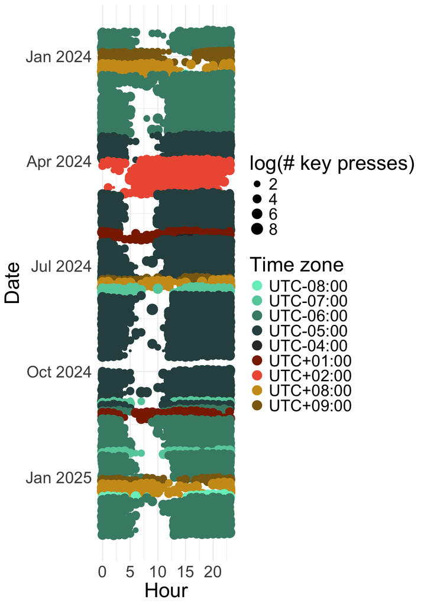

```r
# t_date <- scales::transform_date()

min_date <- as.Date(min(dat_hour_p3$date) - days(1))
max_date <- as.Date(max(dat_hour_p3$date) + days(1))


ggplot(dat_hour_p3) +
  geom_point(aes(hour, date, size = log(totalKeyPresses), color = timezone)) +
  scale_y_continuous(
    limits = c(max_date, min_date), # Reversed
    transform = c("date", "reverse")
  ) +
  scale_color_manual(values = c(
    "aquamarine2", "aquamarine3", "aquamarine4", "darkslategray", "gray20",
    "orangered4", "tomato2",
    "goldenrod3", "goldenrod4"
  )) +
  labs(x = "Hour", y = "Date", color = "Time zone", size = "log(# key presses)") +
  # ylim(min_date, max_date) +
  guides(color = guide_legend(override.aes = list(size = 5))) +
  theme_minimal() +
  theme(text = element_text(size = 24))
```

# Cosine similarity

This was a candidate metric for capturing phase shifts in someone’s diurnal rhythm before we settled on the circular mean approach.

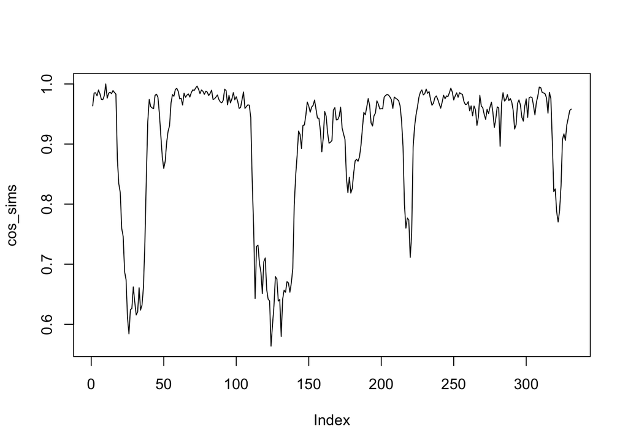

```r
svd_mat <- matrix(dat_svd$value, ncol = 24, byrow = TRUE)

# plot(c(t(svd_mat[1:30,])), type = "l")

# null_vector = numeric(length = 24)
# null_vector[1] = 1

null_vector <- svd_mat[10,]

null_mag <- sqrt(sum(null_vector^2))

# Vector of dot products
dots = svd_mat %*% null_vector

cos_sims = dots / (sqrt(rowSums(svd_mat^2)) * null_mag)

plot(cos_sims, type = "l")
```

```r
dat_svd$cos_sim <- rep(cos_sims, each = 24)

dat_svd
```

```
## Ignoring unknown labels:
## • fill : "Time zone"
```

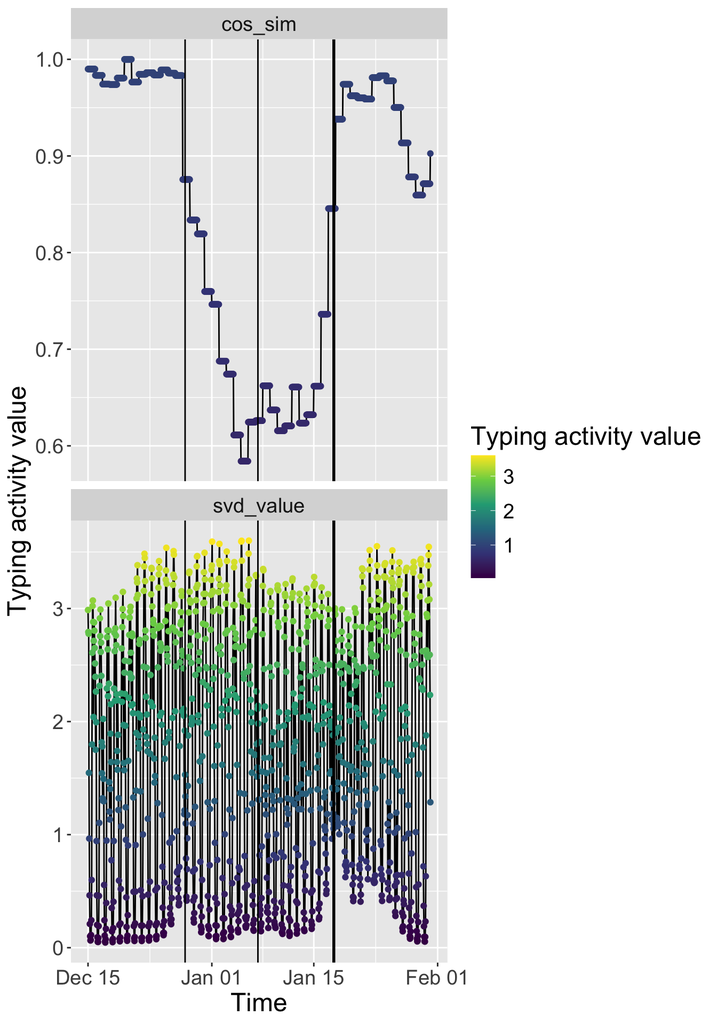

```r
zoom_start_dt <- as_datetime(zoom_start)
zoom_end_dt <- as_datetime(zoom_end)

dat_svd_ts_longer <- dat_svd %>%
  mutate(timestamp = as_datetime(date) + hours(hour)) %>%
  filter(timestamp >= zoom_start_dt,
         timestamp <= zoom_end_dt) %>%
  rename(svd_value = value) %>%
  pivot_longer(c(svd_value, cos_sim), names_to = "variable")

ggplot(dat_svd_ts_longer) +
  # geom_rect(aes(xmin = session_timestamp, xmax = next_timestamp,
  #               ymin = -1, ymax = 5, fill = timezone),
  #           alpha = 0.5, data = dat_transition) +
  geom_line(aes(timestamp, value)) +
  geom_point(aes(timestamp, value, color = value)) +
  scale_color_continuous(type = "viridis") +
  scale_fill_manual(values = c(
    "aquamarine2", "aquamarine3", "aquamarine4", "darkslategray", "gray20",
    "black", "orangered4", "tomato2",
    "goldenrod3", "goldenrod4"
  )) +
  geom_vline(aes(xintercept = session_timestamp), data = dat_transition) +
  labs(x = NULL, y = "Typing activity value", color = "Typing activity value", fill = "Time zone") +
  facet_wrap(~ variable, ncol = 1, scales = "free_y") +
  coord_cartesian(xlim = c(zoom_start_dt, zoom_end_dt)) +
  xlab("Time") +
  theme(text = element_text(size = 18))
```

# TOD prediction

Showing that the GRSVD value and time of day are linked. If this link gets shifted by a new time zone, this can be quantified as an error in predicting the GRSVD value from the time of day, and this in turn can be another quantification of the diurnal rhythm phase.

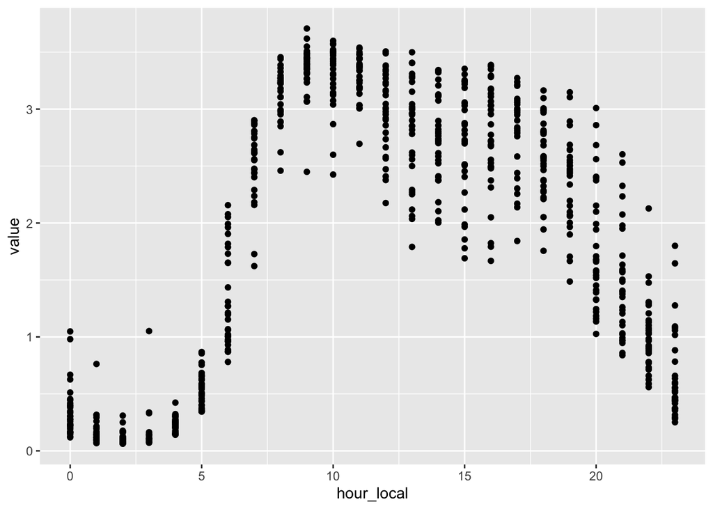

```r
# Stable period
stable_start <- ymd("2024-08-01")
stable_end <- ymd("2024-08-31")

dat_svd_stable <- dat_svd %>%
  filter(between(date, stable_start, stable_end)) %>%
  mutate(hour_local = (hour - 6) %% 24)

ggplot(dat_svd_stable, aes(hour_local, value)) +
  geom_point()
```

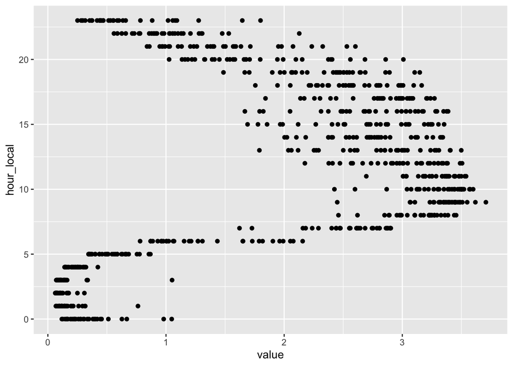

```r
# Shows that hour_local ~ value is not a function
ggplot(dat_svd_stable, aes(value, hour_local)) +
  geom_point()
```

Cosine basis expansion does not quite capture the pattern.

```r
m_tod_1 <- lm(value ~ cos(2*pi / 24 * hour_local) + hour_local, dat_svd_stable)

summary(m_tod_1)
```

```
##
## Call:
## lm(formula = value ~ cos(2 * pi/24 * hour_local) + hour_local,
##     data = dat_svd_stable)
##
## Residuals:
##      Min       1Q   Median       3Q      Max
## -1.53818 -0.38601  0.01006  0.38236  1.42431
##
## Coefficients:
##                              Estimate Std. Error t value Pr(>|t|)
## (Intercept)                  1.319415   0.037241   35.43   <2e-16 ***
## cos(2 * pi/24 * hour_local) -1.422696   0.027199  -52.31   <2e-16 ***
## hour_local                   0.048840   0.002778   17.58   <2e-16 ***
## ---
## Signif. codes:  0 '***' 0.001 '**' 0.01 '*' 0.05 '.' 0.1 ' ' 1
##
## Residual standard error: 0.5218 on 741 degrees of freedom
## Multiple R-squared:  0.8151, Adjusted R-squared:  0.8146
## F-statistic:  1634 on 2 and 741 DF,  p-value: < 2.2e-16
```

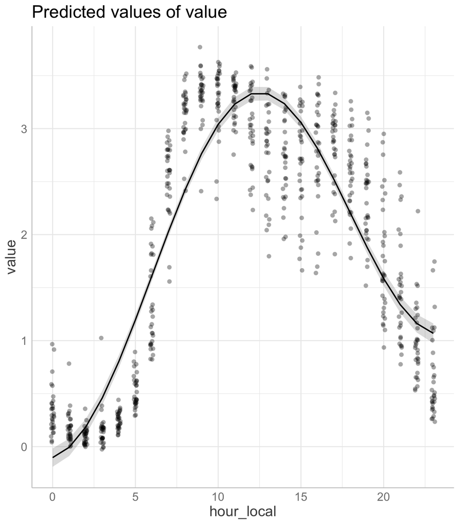

```r
plot(predict_response(m_tod_1, terms = "hour_local"), show_data = TRUE, jitter = 0.1) +
  theme(text = element_text(size = 16))
```

LOESS does a slightly better job.

```r
m_tod_2 <- loess(value ~ hour_local, dat_svd_stable, span = 0.5)

summary(m_tod_2)
```

```
## Call:
## loess(formula = value ~ hour_local, data = dat_svd_stable, span = 0.5)
##
## Number of Observations: 744
## Equivalent Number of Parameters: 6.26
## Residual Standard Error: 0.362
## Trace of smoother matrix: 6.87  (exact)
##
## Control settings:
##   span     :  0.5
##   degree   :  2
##   family   :  gaussian
##   surface  :  interpolate      cell = 0.2
##   normalize:  TRUE
##  parametric:  FALSE
## drop.square:  FALSE
```